# act_report

## Report: act_report

In this section of the report, I will reproduce the analyses/insights and the visualizations I made

Below is the visualization of my first analysis

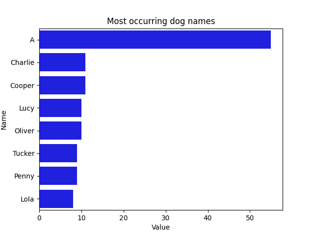

I inspected the unique values of the name column of the copy of df dataframe to have a look at all the different unique names in the dataframe. I wanted to find the most occurring names of dogs in the df_copy dataframe.

This was what I found:

**Note:** However, I must add that the names weren't properly cleaned thus my visualization was based on this consideration.

##### With the second analysis,I performed descriptive statistics on the source column of the cleaned df dataframe(df_new)

and also performed the value count operation on it to get the count on the various tweet sources.

These are the results of all the operations:

***There are four tweet sources, namely :***

- Twitter for iPhone
- Vine - Make a Scene
- Twitter Web Client
- TweetDeck

**There was a total of 2173 tweets made from all the sources combined.Among the sources , the top/most tweets were made from an iPhone with a total of 2041 tweets followed by Vine with a smaller value of 90, the source with the least tweet made from was TweetDeck with a value of 11 and the last but not least source was from Twitter Web Client with a tweet value of 31**

Below is the visualization of the four tweet sources and their respective tweet counts(values)

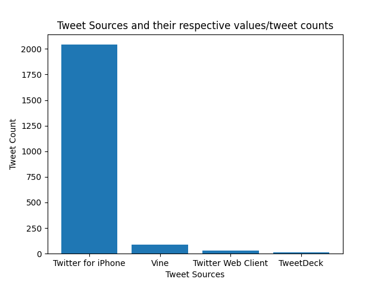

#### Finally, the last analysis was based on the timestamp of the tweets, and this is what I found:

##### There was a total of 2173 tweets. The top tweet was made on 1st August 2017, the first tweet was on 15th November, 2015 and the last on 1st August, 2017.